# Fecundity process investigation

Niklas Neisse

2026-09-18

# Introduction

This report documents the fecundity process as it is currently implemented for *Eriogonum longifolium*. It is intended as an exploratory description of the current data structure and fitted fecundity components.

The report focuses on:

1. flowering probability,
2. number of scapes conditional on flowering,
3. the scapes-to-recruits transition,
4. recruit size distribution, and
5. how these components are combined in the IPM fecundity process.

Only the currently selected models are fitted here. No model selection is repeated in this report.

# Setup

```r
knitr::opts_chunk$set(
  echo = TRUE,
  message = FALSE,
  warning = FALSE,
  fig.align = 'center')

library(MASS)
library(tidyverse)
library(lme4)

set.seed(100)
options(stringsAsFactors = FALSE)

v_head <- 'archbold'
v_species <- 'Eriogonum longifolium'
v_years_re <- c()

v_sp_abb <- tolower(
  gsub(
    ' ',
    '',
    paste(
      substr(
        unlist(strsplit(v_species, ' ')),
        1, 2),
      collapse = '')))

v_ggp_suffix <- paste(
  tools::toTitleCase(v_head),
  '-',
  v_species)

dir_data <- file.path(
  'C:', 'code', 'RUPDemo_IPMs',
  v_head,
  'data',
  v_sp_abb)

data_file <- file.path(
  dir_data,
  paste0(
    'ab_',
    v_sp_abb,
    '_df_workdata_260820.csv'))

if (!file.exists(data_file)) {
  stop(
    'Data file not found: ',
    data_file,
    '\nKnit this report from the project root or update data_file.')
}

ctrl_glmer <- glmerControl(
  optimizer = 'bobyqa',
  optCtrl = list(
    maxfun = 2e5))

ctrl_re <- glmerControl(
  optimizer = 'bobyqa',
  optCtrl = list(
    maxfun = 2e5))
```

# Data

The same working-data file and basic data preparation used in the current IPM analysis are used here.

```r
disturbance_case_levels <- c(
  'Undisturbed',
  'Current-year fire',
  'Previous-year fire',
  'Fire in both years')

df <- read.csv(
  data_file) %>%
  mutate(
    disturbance = as.numeric(
      dist_transition),
    disturbance_prev = as.numeric(
      disturbance_prev),
    year = as.integer(year),
    row_type = as.character(
      row_type),
    disturbance_case = factor(
      paste0(
        disturbance,
        disturbance_prev),
      levels = c(
        '00', '10', '01', '11'),
      labels = disturbance_case_levels)) %>%
  filter(
    !is.na(year),
    !(year %in% v_years_re))

df_ind <- df %>%
  filter(
    row_type == 'individual')

df_re_all <- df %>%
  filter(
    row_type == 'recruitment')

df_re <- df_re_all %>%
  filter(
    recruitment_complete,
    !is.na(recruits_simple))
```

# Fecundity as currently implemented

The current fecundity process has three fitted demographic components followed by a recruit-size distribution:

- flowering probability is modeled at the individual-year level;
- scape number is modeled at the individual-year level conditional on flowering;
- scapes and recruits are summed to the site-population-year level for the scapes-to-recruits model;
- the fitted recruitment relationship is converted back to recruits per scape before entering the individual-level IPM fecundity calculation;
- recruits are distributed across recruit size using the observed seedling-size distribution.

Previous-year fire is used in flowering and scape production. Current-year fire is used in the scapes-to-recruits component.

# Flowering probability

## Flowering data

```r
df_fl <- df %>%
  filter(
    state == 'active',
    !is.na(flower),
    size_t0 > 0,
    is.finite(logsize_t0),
    is.finite(logsize_t0_2),
    is.finite(logsize_t0_3),
    !is.na(disturbance_prev)) %>%
  mutate(
    year = factor(year),
    disturbance_prev = as.numeric(
      disturbance_prev))
```

## Selected flowering model

The currently selected flowering model contains cubic size dependence, previous-year fire, and a year random intercept.

```r
mod_fl_bestfit <- glmer(
  flower ~
    logsize_t0 +
    logsize_t0_2 +
    logsize_t0_3 +
    disturbance_prev +
    (1 | year),
  data = df_fl,
  family = binomial,
  control = ctrl_glmer)

formula(mod_fl_bestfit)
```

```
## flower ~ logsize_t0 + logsize_t0_2 + logsize_t0_3 + disturbance_prev +
##     (1 | year)
```

```r
summary(mod_fl_bestfit)
```

```
## Generalized linear mixed model fit by maximum likelihood (Laplace
##   Approximation) [glmerMod]
##  Family: binomial  ( logit )
## Formula:
## flower ~ logsize_t0 + logsize_t0_2 + logsize_t0_3 + disturbance_prev +
##     (1 | year)
##    Data: df_fl
## Control: ctrl_glmer
##
##       AIC       BIC    logLik -2*log(L)  df.resid
##    7981.7    8027.0   -3984.8    7969.7     14008
##
## Scaled residuals:
##     Min      1Q  Median      3Q     Max
## -1.5508 -0.3318 -0.2167 -0.1051 26.5179
##
## Random effects:
##  Groups Name        Variance Std.Dev.
##  year   (Intercept) 0.8206   0.9059
## Number of obs: 14014, groups:  year, 22
##
## Fixed effects:
##                  Estimate Std. Error z value Pr(>|z|)
## (Intercept)      -6.09891    0.47606 -12.811  < 2e-16 ***
## logsize_t0       -1.13314    0.38690  -2.929   0.0034 **
## logsize_t0_2      1.58543    0.23593   6.720 1.82e-11 ***
## logsize_t0_3     -0.25297    0.04398  -5.751 8.85e-09 ***
## disturbance_prev  2.36125    0.11173  21.134  < 2e-16 ***
## ---
## Signif. codes:  0 '***' 0.001 '**' 0.01 '*' 0.05 '.' 0.1 ' ' 1
##
## Correlation of Fixed Effects:
##             (Intr) lgsz_0 lg_0_2 lg_0_3
## logsize_t0  -0.462
## logsiz_t0_2 -0.102 -0.789
## logsiz_t0_3  0.295  0.615 -0.967
## dstrbnc_prv -0.072 -0.029  0.040 -0.027
```

## Flowering data coverage

The first table shows individual-year records. The second removes repeated individuals within a quadrat-year and therefore shows the disturbance coverage at the quadrat-year level.

```r
df_fl %>%
  count(
    disturbance_prev,
    name = 'n_individual_years') %>%
  as_tibble() %>%
  print(n = Inf)
```

```
## # A tibble: 2 × 2
##   disturbance_prev n_individual_years
##              <dbl>              <int>
## 1                0              12717
## 2                1               1297
```

```r
df_fl %>%
  distinct(
    site,
    pop,
    qu,
    year,
    disturbance_prev) %>%
  count(
    disturbance_prev,
    name = 'n_quadrat_years') %>%
  as_tibble() %>%
  print(n = Inf)
```

```
## # A tibble: 2 × 2
##   disturbance_prev n_quadrat_years
##              <dbl>           <int>
## 1                0             997
## 2                1              84
```

## Mean flowering relationship

The mean relationship uses fixed effects only. The year random effect is excluded with `re.form = NA`.

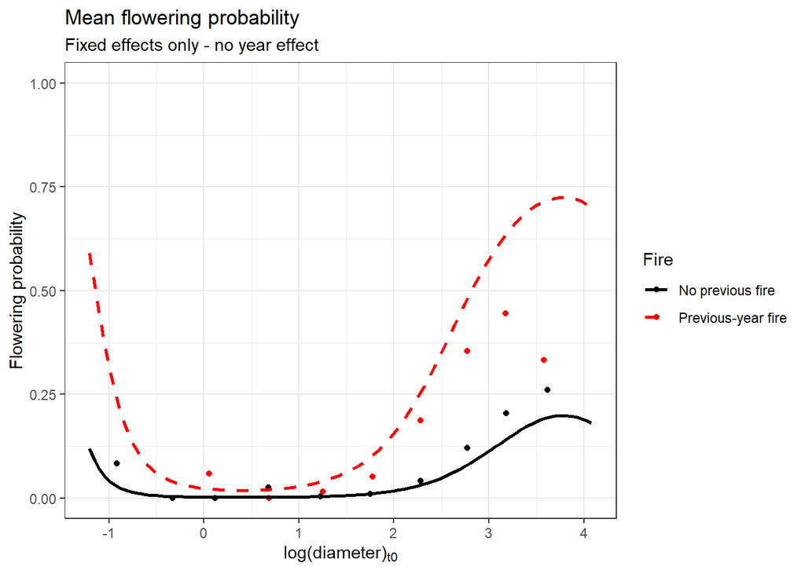

```r
df_fl_mean_pred <- tidyr::expand_grid(
  logsize_t0 = seq(
    min(
      df_fl$logsize_t0,
      na.rm = TRUE),
    max(
      df_fl$logsize_t0,
      na.rm = TRUE),
    length.out = 100),
  disturbance_prev = c(0, 1)) %>%
  mutate(
    logsize_t0_2 = logsize_t0^2,
    logsize_t0_3 = logsize_t0^3,
    year = factor(
      levels(df_fl$year)[1],
      levels = levels(df_fl$year)))

df_fl_mean_pred <- df_fl_mean_pred %>%
  mutate(
    flower = predict(
      mod_fl_bestfit,
      newdata = df_fl_mean_pred,
      type = 'response',
      re.form = NA,
      allow.new.levels = TRUE))

df_fl_mean_binned <- df_fl %>%
  mutate(
    bin = cut(
      logsize_t0,
      breaks = 10)) %>%
  group_by(
    bin,
    disturbance_prev) %>%
  summarise(
    logsize_t0 = mean(
      logsize_t0,
      na.rm = TRUE),
    flower = mean(
      flower,
      na.rm = TRUE),
    n = n(),
    .groups = 'drop') %>%
  filter(
    !is.na(logsize_t0),
    n > 0)

fig_fl_mean <- ggplot() +
  geom_point(
    data = df_fl_mean_binned,
    aes(
      logsize_t0,
      flower,
      color = factor(
        disturbance_prev))) +
  geom_line(
    data = df_fl_mean_pred,
    aes(
      logsize_t0,
      flower,
      color = factor(
        disturbance_prev),
      linetype = factor(
        disturbance_prev)),
    linewidth = 1) +
  scale_color_manual(
    values = c(
      '0' = 'black',
      '1' = 'red'),
    labels = c(
      '0' = 'No previous fire',
      '1' = 'Previous-year fire'),
    name = 'Fire') +
  scale_linetype_manual(
    values = c(
      '0' = 'solid',
      '1' = 'dashed'),
    labels = c(
      '0' = 'No previous fire',
      '1' = 'Previous-year fire'),
    name = 'Fire') +
  labs(
    title = 'Mean flowering probability',
    subtitle = 'Fixed effects only - no year effect',
    x = expression(
      'log(diameter)'[t0]),
    y = 'Flowering probability') +
  coord_cartesian(
    ylim = c(0, 1)) +
  theme_bw()

fig_fl_mean
```

## Flowering relationships by year

The same model is shown for all years in one panel. The corresponding year random effect is included with `re.form = NULL`.

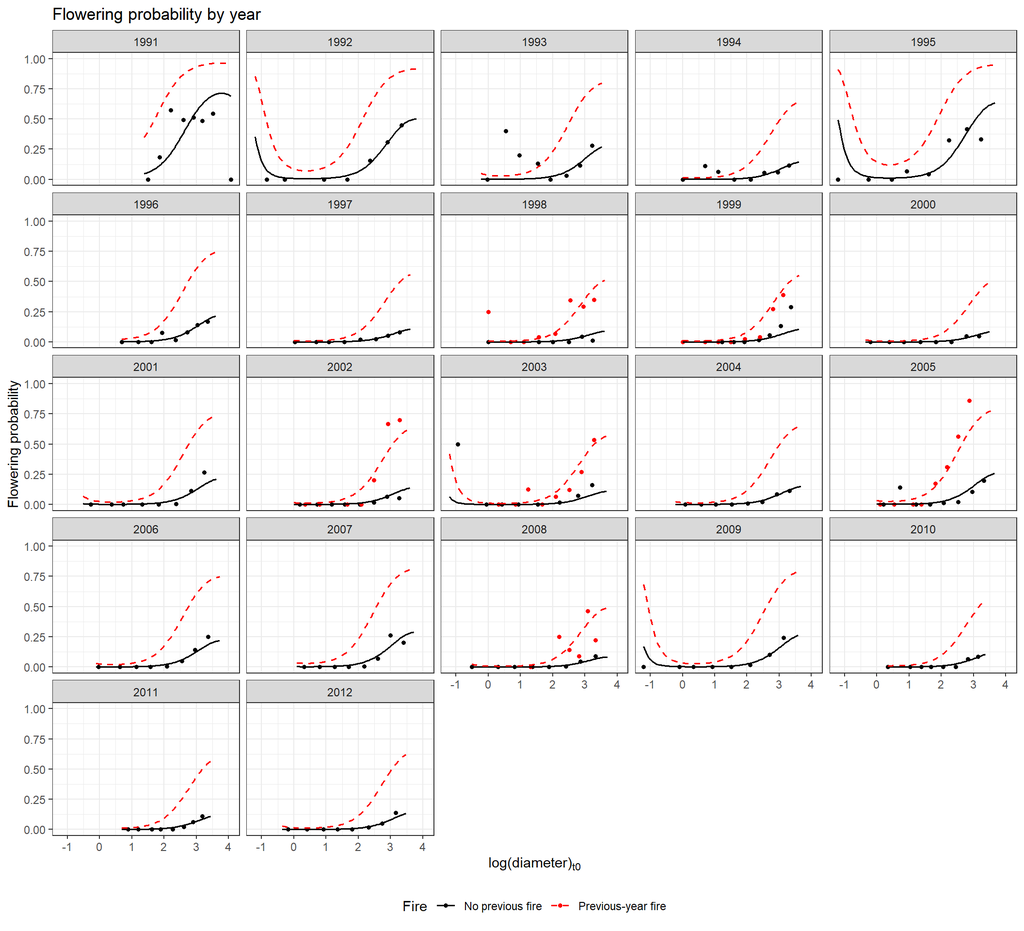

```r
df_fl_year_pred <- map_dfr(
  levels(df_fl$year),
  function(year_i) {
    df_i <- df_fl %>%
      filter(year == year_i)

    x <- seq(
      min(df_i$logsize_t0, na.rm = TRUE),
      max(df_i$logsize_t0, na.rm = TRUE),
      length.out = 100)

    pred_i <- tidyr::expand_grid(
  logsize_t0 = x,
  disturbance_prev = c(0, 1)) %>%
  mutate(
    logsize_t0_2 = logsize_t0^2,
    logsize_t0_3 = logsize_t0^3,
    year = factor(
      year_i,
      levels = levels(df_fl$year)))

pred_i %>%
  mutate(
    flower = predict(
      mod_fl_bestfit,
      newdata = pred_i,
      type = 'response',
      re.form = NULL,
      allow.new.levels = TRUE))
  })

df_fl_year_obs <- df_fl %>%
  group_by(year, disturbance_prev) %>%
  mutate(
    bin = cut(
      logsize_t0,
      breaks = 8)) %>%
  group_by(
    year,
    disturbance_prev,
    bin) %>%
  summarise(
    logsize_t0 = mean(logsize_t0, na.rm = TRUE),
    flower = mean(flower, na.rm = TRUE),
    n = n(),
    .groups = 'drop') %>%
  filter(
    !is.na(logsize_t0),
    n > 0)

fig_fl_year <- ggplot() +
  geom_point(
    data = df_fl_year_obs,
    aes(
      logsize_t0,
      flower,
      color = factor(disturbance_prev)),
    size = 1.2) +
  geom_line(
    data = df_fl_year_pred,
    aes(
      logsize_t0,
      flower,
      color = factor(disturbance_prev),
      linetype = factor(disturbance_prev)),
    linewidth = 0.7) +
  facet_wrap(
    ~ year,
    ncol = 5) +
  scale_color_manual(
    values = c(
      '0' = 'black',
      '1' = 'red'),
    labels = c(
      '0' = 'No previous fire',
      '1' = 'Previous-year fire'),
    name = 'Fire') +
  scale_linetype_manual(
    values = c(
      '0' = 'solid',
      '1' = 'dashed'),
    labels = c(
      '0' = 'No previous fire',
      '1' = 'Previous-year fire'),
    name = 'Fire') +
  coord_cartesian(
    ylim = c(0, 1)) +
  labs(
    title = 'Flowering probability by year',
    x = expression('log(diameter)'[t0]),
    y = 'Flowering probability') +
  theme_bw() +
  theme(
    legend.position = 'bottom')

fig_fl_year
```

# Number of scapes conditional on flowering

## Scape-number data

```r
df_fl_cond <- df_fl %>%
  filter(
    flower == 1,
    !is.na(fl_nr),
    fl_nr > 0,
    fl_nr == round(fl_nr),
    !is.na(disturbance_prev)) %>%
  mutate(
    year = factor(year))
```

## Selected scape-number model

The currently selected model contains cubic size dependence, previous-year fire, and a year random intercept.

```r
mod_fl_n_bestfit <- glmer.nb(
  fl_nr ~
    logsize_t0 +
    logsize_t0_2 +
    logsize_t0_3 +
    disturbance_prev +
    (1 | year),
  data = df_fl_cond,
  control = ctrl_glmer)

formula(mod_fl_n_bestfit)
```

```
## fl_nr ~ logsize_t0 + logsize_t0_2 + logsize_t0_3 + disturbance_prev +
##     (1 | year)
```

```r
summary(mod_fl_n_bestfit)
```

```
## Generalized linear mixed model fit by maximum likelihood (Laplace
##   Approximation) [glmerMod]
##  Family: Negative Binomial(48.6215)  ( log )
## Formula: fl_nr ~ logsize_t0 + logsize_t0_2 + logsize_t0_3 + disturbance_prev +
##     (1 | year)
##    Data: df_fl_cond
## Control: ctrl_glmer
##
##       AIC       BIC    logLik -2*log(L)  df.resid
##    4931.3    4969.2   -2458.6    4917.3      1654
##
## Scaled residuals:
##     Min      1Q  Median      3Q     Max
## -1.3213 -0.4636 -0.1915  0.1216 16.6428
##
## Random effects:
##  Groups Name        Variance Std.Dev.
##  year   (Intercept) 0.07955  0.2821
## Number of obs: 1661, groups:  year, 22
##
## Fixed effects:
##                  Estimate Std. Error z value Pr(>|z|)
## (Intercept)       0.20352    0.31015   0.656  0.51169
## logsize_t0       -1.19057    0.37418  -3.182  0.00146 **
## logsize_t0_2      0.61789    0.22761   2.715  0.00663 **
## logsize_t0_3     -0.07085    0.03918  -1.808  0.07057 .
## disturbance_prev  0.35165    0.08159   4.310 1.63e-05 ***
## ---
## Signif. codes:  0 '***' 0.001 '**' 0.01 '*' 0.05 '.' 0.1 ' ' 1
##
## Correlation of Fixed Effects:
##             (Intr) lgsz_0 lg_0_2 lg_0_3
## logsize_t0  -0.437
## logsiz_t0_2  0.029 -0.901
## logsiz_t0_3  0.123  0.808 -0.982
## dstrbnc_prv -0.011 -0.099  0.070 -0.046
## optimizer (bobyqa) convergence code: 0 (OK)
## Model failed to converge with max|grad| = 0.00384527 (tol = 0.002, component 1)
##   See ?lme4::convergence and ?lme4::troubleshooting.
```

## Scape-number data coverage

```r
df_fl_cond %>%
  count(
    disturbance_prev,
    name = 'n_flowering_individual_years') %>%
  as_tibble() %>%
  print(n = Inf)
```

```
## # A tibble: 2 × 2
##   disturbance_prev n_flowering_individual_years
##              <dbl>                        <int>
## 1                0                         1306
## 2                1                          355
```

```r
df_fl_cond %>%
  distinct(
    site,
    pop,
    qu,
    year,
    disturbance_prev) %>%
  count(
    disturbance_prev,
    name = 'n_quadrat_years') %>%
  as_tibble() %>%
  print(n = Inf)
```

```
## # A tibble: 2 × 2
##   disturbance_prev n_quadrat_years
##              <dbl>           <int>
## 1                0             429
## 2                1              69
```

## Mean scape-number relationship

The mean relationship uses fixed effects only.

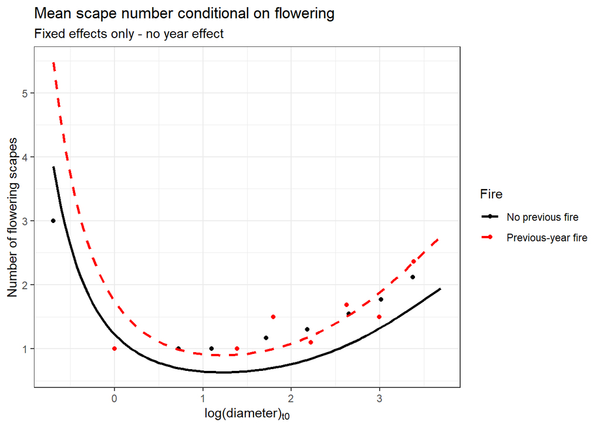

```r
df_fl_n_mean_pred <- tidyr::expand_grid(
  logsize_t0 = seq(
    min(
      df_fl_cond$logsize_t0,
      na.rm = TRUE),
    max(
      df_fl_cond$logsize_t0,
      na.rm = TRUE),
    length.out = 100),
  disturbance_prev = c(0, 1)) %>%
  mutate(
    logsize_t0_2 = logsize_t0^2,
    logsize_t0_3 = logsize_t0^3,
    year = factor(
      levels(df_fl_cond$year)[1],
      levels = levels(
        df_fl_cond$year)))

df_fl_n_mean_pred <- df_fl_n_mean_pred %>%
  mutate(
    fl_nr = predict(
      mod_fl_n_bestfit,
      newdata = df_fl_n_mean_pred,
      type = 'response',
      re.form = NA,
      allow.new.levels = TRUE))

df_fl_n_mean_binned <- df_fl_cond %>%
  mutate(
    bin = cut(
      logsize_t0,
      breaks = 10)) %>%
  group_by(
    bin,
    disturbance_prev) %>%
  summarise(
    logsize_t0 = mean(
      logsize_t0,
      na.rm = TRUE),
    fl_nr = mean(
      fl_nr,
      na.rm = TRUE),
    n = n(),
    .groups = 'drop') %>%
  filter(
    !is.na(logsize_t0),
    n > 0)

fig_fl_n_mean <- ggplot() +
  geom_point(
    data = df_fl_n_mean_binned,
    aes(
      logsize_t0,
      fl_nr,
      color = factor(
        disturbance_prev))) +
  geom_line(
    data = df_fl_n_mean_pred,
    aes(
      logsize_t0,
      fl_nr,
      color = factor(
        disturbance_prev),
      linetype = factor(
        disturbance_prev)),
    linewidth = 1) +
  scale_color_manual(
    values = c(
      '0' = 'black',
      '1' = 'red'),
    labels = c(
      '0' = 'No previous fire',
      '1' = 'Previous-year fire'),
    name = 'Fire') +
  scale_linetype_manual(
    values = c(
      '0' = 'solid',
      '1' = 'dashed'),
    labels = c(
      '0' = 'No previous fire',
      '1' = 'Previous-year fire'),
    name = 'Fire') +
  labs(
    title = 'Mean scape number conditional on flowering',
    subtitle = 'Fixed effects only - no year effect',
    x = expression(
      'log(diameter)'[t0]),
    y = 'Number of flowering scapes') +
  theme_bw()

fig_fl_n_mean
```

## Scape-number relationships by year

The selected scape-number model is shown for all years in one panel. The corresponding year random effect is included.

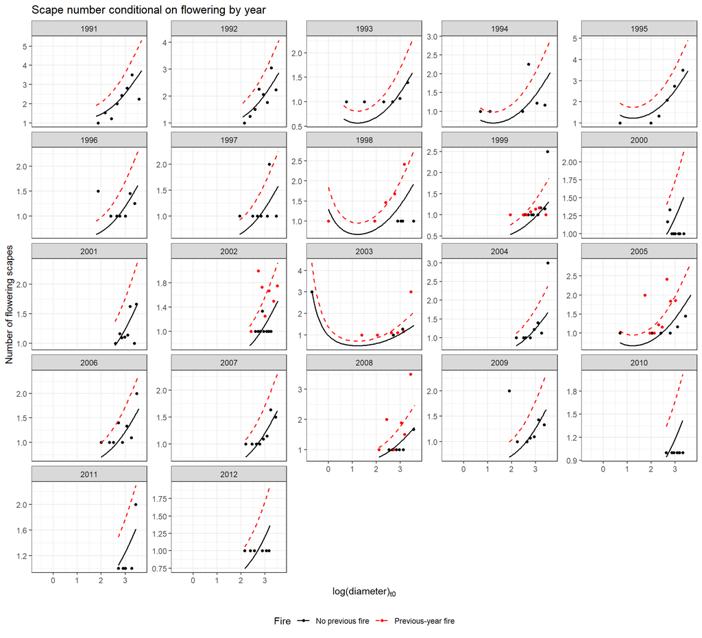

```r
df_fl_n_year_pred <- map_dfr(
  levels(df_fl_cond$year),
  function(year_i) {
    df_i <- df_fl_cond %>%
      filter(year == year_i)

    x <- seq(
      min(df_i$logsize_t0, na.rm = TRUE),
      max(df_i$logsize_t0, na.rm = TRUE),
      length.out = 100)

    pred_i <- tidyr::expand_grid(
  logsize_t0 = x,
  disturbance_prev = c(0, 1)) %>%
  mutate(
    logsize_t0_2 = logsize_t0^2,
    logsize_t0_3 = logsize_t0^3,
    year = factor(
      year_i,
      levels = levels(df_fl_cond$year)))

pred_i %>%
  mutate(
    fl_nr = predict(
      mod_fl_n_bestfit,
      newdata = pred_i,
      type = 'response',
      re.form = NULL,
      allow.new.levels = TRUE))
  })

df_fl_n_year_obs <- df_fl_cond %>%
  group_by(year, disturbance_prev) %>%
  mutate(
    bin = cut(
      logsize_t0,
      breaks = 8)) %>%
  group_by(
    year,
    disturbance_prev,
    bin) %>%
  summarise(
    logsize_t0 = mean(logsize_t0, na.rm = TRUE),
    fl_nr = mean(fl_nr, na.rm = TRUE),
    n = n(),
    .groups = 'drop') %>%
  filter(
    !is.na(logsize_t0),
    n > 0)

fig_fl_n_year <- ggplot() +
  geom_point(
    data = df_fl_n_year_obs,
    aes(
      logsize_t0,
      fl_nr,
      color = factor(disturbance_prev)),
    size = 1.2) +
  geom_line(
    data = df_fl_n_year_pred,
    aes(
      logsize_t0,
      fl_nr,
      color = factor(disturbance_prev),
      linetype = factor(disturbance_prev)),
    linewidth = 0.7) +
  facet_wrap(
    ~ year,
    ncol = 5,
    scales = 'free_y') +
  scale_color_manual(
    values = c(
      '0' = 'black',
      '1' = 'red'),
    labels = c(
      '0' = 'No previous fire',
      '1' = 'Previous-year fire'),
    name = 'Fire') +
  scale_linetype_manual(
    values = c(
      '0' = 'solid',
      '1' = 'dashed'),
    labels = c(
      '0' = 'No previous fire',
      '1' = 'Previous-year fire'),
    name = 'Fire') +
  labs(
    title = 'Scape number conditional on flowering by year',
    x = expression('log(diameter)'[t0]),
    y = 'Number of flowering scapes') +
  theme_bw() +
  theme(
    legend.position = 'bottom')

fig_fl_n_year
```

# Scape bookkeeping

The recruitment rows contain `nr_scapes`, while individual plant records contain `fl_nr`. The following check compares both quantities after individual scape counts are summed to the quadrat-year level.

```r
df_scapes_ind_quad <- df_ind %>%
  filter(
    !is.na(fl_nr)) %>%
  group_by(
    site,
    pop,
    qu,
    year) %>%
  summarise(
    n_individual_records = n(),
    scapes_from_individuals = sum(
      fl_nr,
      na.rm = TRUE),
    .groups = 'drop')

df_scapes_re_quad <- df_re %>%
  filter(
    !is.na(nr_scapes)) %>%
  group_by(
    site,
    pop,
    qu,
    year) %>%
  summarise(
    scapes_from_recruitment = sum(
      nr_scapes,
      na.rm = TRUE),
    recruits = sum(
      recruits_simple,
      na.rm = TRUE),
    .groups = 'drop')

df_scape_compare <- full_join(
  df_scapes_ind_quad,
  df_scapes_re_quad,
  by = c(
    'site',
    'pop',
    'qu',
    'year')) %>%
  mutate(
    difference =
      scapes_from_recruitment -
      scapes_from_individuals)

df_scape_compare %>%
  summarise(
    n_quadrat_years = n(),
    n_both_available = sum(
      !is.na(
        scapes_from_individuals) &
        !is.na(
          scapes_from_recruitment)),
    mean_individual_scapes = mean(
      scapes_from_individuals,
      na.rm = TRUE),
    mean_recruitment_scapes = mean(
      scapes_from_recruitment,
      na.rm = TRUE),
    mean_difference = mean(
      difference,
      na.rm = TRUE),
    max_abs_difference = max(
      abs(difference),
      na.rm = TRUE),
    correlation = cor(
      scapes_from_individuals,
      scapes_from_recruitment,
      use = 'complete.obs')) %>%
  as_tibble() %>%
  print(n = Inf)
```

```
## # A tibble: 1 × 7
##   n_quadrat_years n_both_available mean_individual_scapes mean_recruitment_sca…¹
##             <int>            <int>                  <dbl>                  <dbl>
## 1            1353             1161                   2.59                   2.67
## # ℹ abbreviated name: ¹mean_recruitment_scapes
## # ℹ 3 more variables: mean_difference <dbl>, max_abs_difference <int>,
## #   correlation <dbl>
```

# Scapes to recruits

## Recruitment data and aggregation

The current scapes-to-recruits model is fitted after aggregation to site-population-year. Scapes and recruits are summed over recruitment quadrats.

A site-population-year is classified as disturbed when at least one contributing quadrat has `disturbance == 1`. This is the current aggregation used in the IPM.

```r
df_sc2re <- df_re %>%
  filter(
    !is.na(nr_scapes),
    !is.na(recruits_simple)) %>%
  group_by(
    site,
    pop,
    year) %>%
  summarise(
    total_scapes = sum(
      nr_scapes),
    recruit_count = sum(
      recruits_simple),
    disturbance = case_when(
      any(
        disturbance == 1,
        na.rm = TRUE) ~ 1,
      any(
        is.na(disturbance)) ~ NA_real_,
      TRUE ~ 0),
    disturbance_prev = case_when(
      any(
        disturbance_prev == 1,
        na.rm = TRUE) ~ 1,
      any(
        is.na(disturbance_prev)) ~ NA_real_,
      TRUE ~ 0),
    .groups = 'drop')

df_sc2re_mod <- df_sc2re %>%
  filter(
    !is.na(total_scapes),
    !is.na(recruit_count),
    !is.na(disturbance),
    !(year %in% v_years_re)) %>%
  mutate(
    year = factor(year),
    disturbance = as.numeric(
      disturbance),
    disturbance_prev = as.numeric(
      disturbance_prev))
```

## Selected scapes-to-recruits model

The currently selected recruitment model uses log-transformed scape number, current-year disturbance, their interaction, and a year random intercept.

```r
mod_re_bestfit <- glmer.nb(
  recruit_count ~
    log1p(total_scapes) *
    disturbance +
    (1 | year),
  data = df_sc2re_mod,
  control = ctrl_re)

formula(mod_re_bestfit)
```

```
## recruit_count ~ log1p(total_scapes) * disturbance + (1 | year)
```

```r
summary(mod_re_bestfit)
```

```
## Generalized linear mixed model fit by maximum likelihood (Laplace
##   Approximation) [glmerMod]
##  Family: Negative Binomial(0.735)  ( log )
## Formula: recruit_count ~ log1p(total_scapes) * disturbance + (1 | year)
##    Data: df_sc2re_mod
## Control: ctrl_re
##
##       AIC       BIC    logLik -2*log(L)  df.resid
##     747.8     764.7    -367.9     735.8       118
##
## Scaled residuals:
##     Min      1Q  Median      3Q     Max
## -0.8164 -0.6651 -0.3981  0.0927  5.8113
##
## Random effects:
##  Groups Name        Variance Std.Dev.
##  year   (Intercept) 0        0
## Number of obs: 124, groups:  year, 22
##
## Fixed effects:
##                                 Estimate Std. Error z value Pr(>|z|)
## (Intercept)                      1.00830    0.21680   4.651 3.31e-06 ***
## log1p(total_scapes)              0.37382    0.08324   4.491 7.09e-06 ***
## disturbance                      3.34526    1.47783   2.264   0.0236 *
## log1p(total_scapes):disturbance -0.93079    0.60453  -1.540   0.1236
## ---
## Signif. codes:  0 '***' 0.001 '**' 0.01 '*' 0.05 '.' 0.1 ' ' 1
##
## Correlation of Fixed Effects:
##             (Intr) lg1(_) dstrbn
## lg1p(ttl_s) -0.844
## disturbance -0.147  0.124
## lg1p(ttl_):  0.116 -0.138 -0.964
## optimizer (bobyqa) convergence code: 0 (OK)
## boundary (singular) fit: see help('isSingular')
```

```r
re_year_sd <- if (
    'year' %in%
      names(
        VarCorr(
          mod_re_bestfit))) {
  attr(
    VarCorr(
      mod_re_bestfit)$year,
    'stddev')[1]
} else {
  0
}

tibble(
  singular = isSingular(
    mod_re_bestfit),
  year_intercept_sd = as.numeric(
    re_year_sd)) %>%
  print(n = Inf)
```

```
## # A tibble: 1 × 2
##   singular year_intercept_sd
##   <lgl>                <dbl>
## 1 TRUE                     0
```

## Recruitment disturbance coverage

```r
df_re %>%
  count(
    disturbance,
    name = 'n_recruitment_quadrat_years') %>%
  as_tibble() %>%
  print(n = Inf)
```

```
## # A tibble: 3 × 2
##   disturbance n_recruitment_quadrat_years
##         <dbl>                       <int>
## 1           0                        1007
## 2           1                          85
## 3          NA                          95
```

```r
df_sc2re_mod %>%
  count(
    disturbance,
    name = 'n_site_pop_years') %>%
  as_tibble() %>%
  print(n = Inf)
```

```
## # A tibble: 2 × 2
##   disturbance n_site_pop_years
##         <dbl>            <int>
## 1           0              114
## 2           1               10
```

The first table describes recruitment disturbance information at the quadrat-year level. The second shows how many observations remain after aggregation to site-population-year.

## Mean scapes-to-recruits relationship

The mean relationship uses fixed effects only.

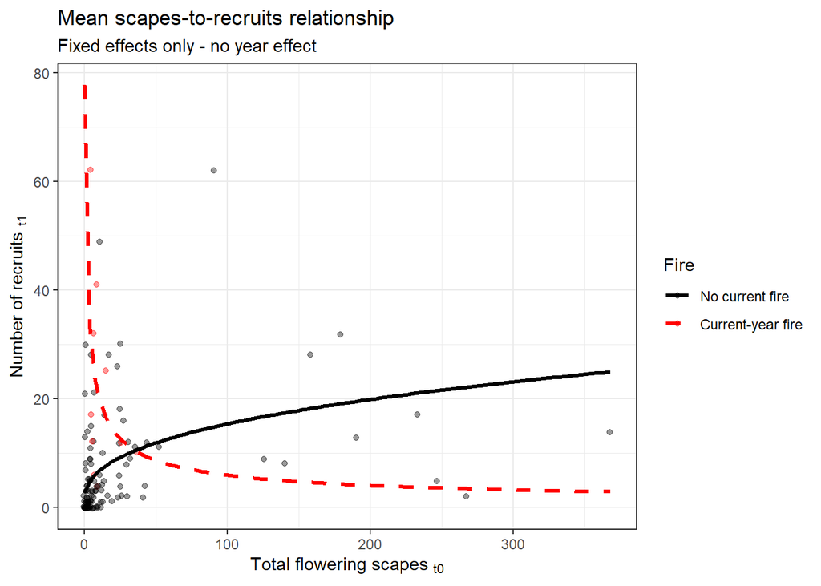

```r
df_sc2re_mean_pred <- tidyr::expand_grid(
  total_scapes = seq(
    0,
    max(
      df_sc2re_mod$total_scapes,
      na.rm = TRUE),
    length.out = 100),
  disturbance = c(0, 1)) %>%
  mutate(
    year = factor(
      levels(
        df_sc2re_mod$year)[1],
      levels = levels(
        df_sc2re_mod$year)))

df_sc2re_mean_pred <- df_sc2re_mean_pred %>%
  mutate(
    recruit_count = predict(
      mod_re_bestfit,
      newdata = df_sc2re_mean_pred,
      type = 'response',
      re.form = NA,
      allow.new.levels = TRUE))

fig_sc2re_mean <- ggplot(
  df_sc2re_mod,
  aes(
    total_scapes,
    recruit_count,
    color = factor(
      disturbance))) +
  geom_jitter(
    height = 0.2,
    width = 0.5,
    alpha = 0.4) +
  geom_line(
    data = df_sc2re_mean_pred,
    aes(
      total_scapes,
      recruit_count,
      color = factor(
        disturbance),
      linetype = factor(
        disturbance)),
    linewidth = 1.2) +
  scale_color_manual(
    values = c(
      '0' = 'black',
      '1' = 'red'),
    labels = c(
      '0' = 'No current fire',
      '1' = 'Current-year fire'),
    name = 'Fire') +
  scale_linetype_manual(
    values = c(
      '0' = 'solid',
      '1' = 'dashed'),
    labels = c(
      '0' = 'No current fire',
      '1' = 'Current-year fire'),
    name = 'Fire') +
  labs(
    title = 'Mean scapes-to-recruits relationship',
    subtitle = 'Fixed effects only - no year effect',
    x = expression(
      'Total flowering scapes '[t0]),
    y = expression(
      'Number of recruits '[t1])) +
  theme_bw()

fig_sc2re_mean
```

## Scapes-to-recruits relationships by year

The selected recruitment model is shown for all years in one panel. The corresponding year random effect is included.

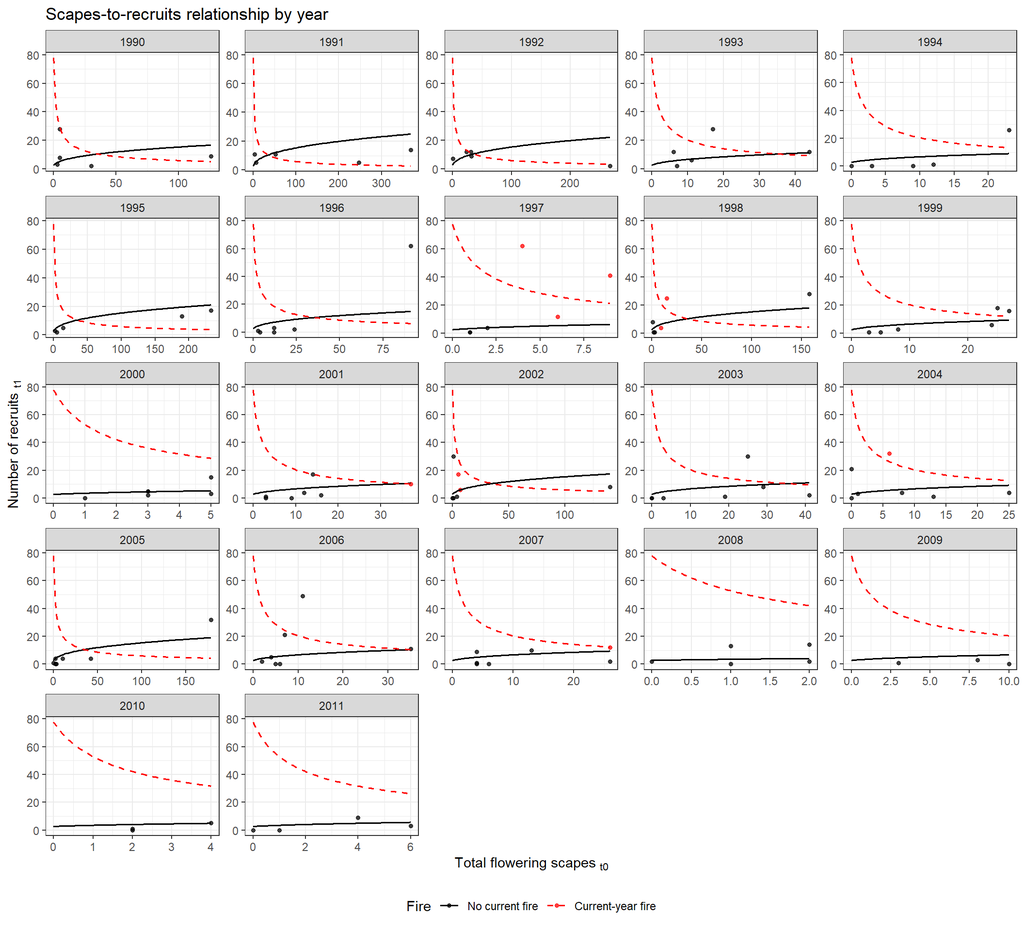

```r
df_re_year_pred <- map_dfr(
  levels(df_sc2re_mod$year),
  function(year_i) {
    df_i <- df_sc2re_mod %>%
      filter(year == year_i)

    x <- seq(
      0,
      max(df_i$total_scapes, na.rm = TRUE),
      length.out = 100)

    pred_i <- tidyr::expand_grid(
  total_scapes = x,
  disturbance = c(0, 1)) %>%
  mutate(
    year = factor(
      year_i,
      levels = levels(df_sc2re_mod$year)))

pred_i %>%
  mutate(
    recruit_count = predict(
      mod_re_bestfit,
      newdata = pred_i,
      type = 'response',
      re.form = NULL,
      allow.new.levels = TRUE))
  })

fig_re_year <- ggplot(
  df_sc2re_mod,
  aes(
    total_scapes,
    recruit_count,
    color = factor(disturbance))) +
  geom_point(
    alpha = 0.75,
    size = 1.3) +
  geom_line(
    data = df_re_year_pred,
    aes(
      total_scapes,
      recruit_count,
      color = factor(disturbance),
      linetype = factor(disturbance)),
    linewidth = 0.7) +
  facet_wrap(
    ~ year,
    ncol = 5,
    scales = 'free') +
  scale_color_manual(
    values = c(
      '0' = 'black',
      '1' = 'red'),
    labels = c(
      '0' = 'No current fire',
      '1' = 'Current-year fire'),
    name = 'Fire') +
  scale_linetype_manual(
    values = c(
      '0' = 'solid',
      '1' = 'dashed'),
    labels = c(
      '0' = 'No current fire',
      '1' = 'Current-year fire'),
    name = 'Fire') +
  labs(
    title = 'Scapes-to-recruits relationship by year',
    x = expression('Total flowering scapes '[t0]),
    y = expression('Number of recruits '[t1])) +
  theme_bw() +
  theme(
    legend.position = 'bottom')

fig_re_year
```

# Recruitment aggregation checks

## Mixed-fire site-population-years

The following table identifies site-population-years in which both disturbed and undisturbed quadrats contribute before aggregation.

```r
df_f2r_fire_trace <- df_re %>%
  filter(
    !is.na(nr_scapes),
    !is.na(recruits_simple)) %>%
  group_by(
    site,
    pop,
    year) %>%
  summarise(
    n_rows = n(),
    n_quadrats = n_distinct(qu),
    n_fire_0 = sum(
      disturbance == 0,
      na.rm = TRUE),
    n_fire_1 = sum(
      disturbance == 1,
      na.rm = TRUE),
    n_fire_na = sum(
      is.na(disturbance)),
    mixed_fire =
      n_fire_0 > 0 &
      n_fire_1 > 0,
    proportion_fire = if_else(
      n_fire_0 + n_fire_1 > 0,
      n_fire_1 /
        (n_fire_0 + n_fire_1),
      NA_real_),
    disturbance_used = case_when(
      any(
        disturbance == 1,
        na.rm = TRUE) ~ 1,
      any(
        is.na(disturbance)) ~ NA_real_,
      TRUE ~ 0),
    total_scapes = sum(
      nr_scapes,
      na.rm = TRUE),
    recruit_count = sum(
      recruits_simple,
      na.rm = TRUE),
    .groups = 'drop')

df_f2r_fire_trace %>%
  summarise(
    n_site_pop_years = n(),
    n_mixed_fire = sum(
      mixed_fire,
      na.rm = TRUE),
    p_mixed_fire = mean(
      mixed_fire,
      na.rm = TRUE),
    mean_prop_fire_when_disturbed = mean(
      proportion_fire[
        disturbance_used == 1],
      na.rm = TRUE),
    min_prop_fire_when_disturbed = min(
      proportion_fire[
        disturbance_used == 1],
      na.rm = TRUE),
    max_prop_fire_when_disturbed = max(
      proportion_fire[
        disturbance_used == 1],
      na.rm = TRUE)) %>%
  as_tibble() %>%
  print(n = Inf)
```

```
## # A tibble: 1 × 6
##   n_site_pop_years n_mixed_fire p_mixed_fire mean_prop_fire_when_disturbed
##              <int>        <int>        <dbl>                         <dbl>
## 1              127            2       0.0157                         0.904
## # ℹ 2 more variables: min_prop_fire_when_disturbed <dbl>,
## #   max_prop_fire_when_disturbed <dbl>
```

```r
df_f2r_fire_trace %>%
  filter(
    mixed_fire) %>%
  as_tibble() %>%
  print(n = Inf)
```

```
## # A tibble: 2 × 13
##    site   pop  year n_rows n_quadrats n_fire_0 n_fire_1 n_fire_na mixed_fire
##   <int> <int> <int>  <int>      <int>    <int>    <int>     <int> <lgl>
## 1     2     8  2001     44         44        9       13        22 TRUE
## 2     2     8  2007     44         44       15       12        17 TRUE
## # ℹ 4 more variables: proportion_fire <dbl>, disturbance_used <dbl>,
## #   total_scapes <int>, recruit_count <int>
```

## Quadrat-level scapes and recruits

This is an empirical check of the data before site-population-year aggregation. It does not replace the current fitted model.

```r
df_f2r_quad <- df_re %>%
  filter(
    !is.na(nr_scapes),
    !is.na(recruits_simple)) %>%
  transmute(
    site,
    pop,
    qu,
    year,
    disturbance,
    disturbance_prev,
    scapes = nr_scapes,
    recruits = recruits_simple)

f2r_quad_summary <- df_f2r_quad %>%
  summarise(
    n_quadrat_years = n(),
    n_zero_scapes = sum(
      scapes == 0),
    p_zero_scapes = mean(
      scapes == 0),
    n_positive_recruits = sum(
      recruits > 0),
    p_positive_recruits = mean(
      recruits > 0),
    n_zero_scapes_positive_recruits = sum(
      scapes == 0 &
        recruits > 0),
    p_zero_scapes_positive_recruits = mean(
      scapes == 0 &
        recruits > 0))

f2r_quad_summary %>%
  as_tibble() %>%
  print(n = Inf)
```

```
## # A tibble: 1 × 7
##   n_quadrat_years n_zero_scapes p_zero_scapes n_positive_recruits
##             <int>         <int>         <dbl>               <int>
## 1            1185           641         0.541                 327
## # ℹ 3 more variables: p_positive_recruits <dbl>,
## #   n_zero_scapes_positive_recruits <int>,
## #   p_zero_scapes_positive_recruits <dbl>
```

```r
df_f2r_quad %>%
  filter(
    !is.na(disturbance)) %>%
  group_by(
    disturbance) %>%
  summarise(
    n_quadrat_years = n(),
    total_scapes = sum(
      scapes,
      na.rm = TRUE),
    total_recruits = sum(
      recruits,
      na.rm = TRUE),
    recruits_per_scape =
      total_recruits /
      total_scapes,
    mean_recruits = mean(
      recruits,
      na.rm = TRUE),
    median_recruits = median(
      recruits,
      na.rm = TRUE),
    p_zero_scapes = mean(
      scapes == 0),
    p_zero_scapes_positive_recruits = mean(
      scapes == 0 &
        recruits > 0),
    .groups = 'drop') %>%
  as_tibble() %>%
  print(n = Inf)
```

```
## # A tibble: 2 × 9
##   disturbance n_quadrat_years total_scapes total_recruits recruits_per_scape
##         <dbl>           <int>        <int>          <int>              <dbl>
## 1           0            1005         2998            803              0.268
## 2           1              85           77            212              2.75
## # ℹ 4 more variables: mean_recruits <dbl>, median_recruits <int>,
## #   p_zero_scapes <dbl>, p_zero_scapes_positive_recruits <dbl>
```

## Quadrat-level empirical scapes-to-recruits plot

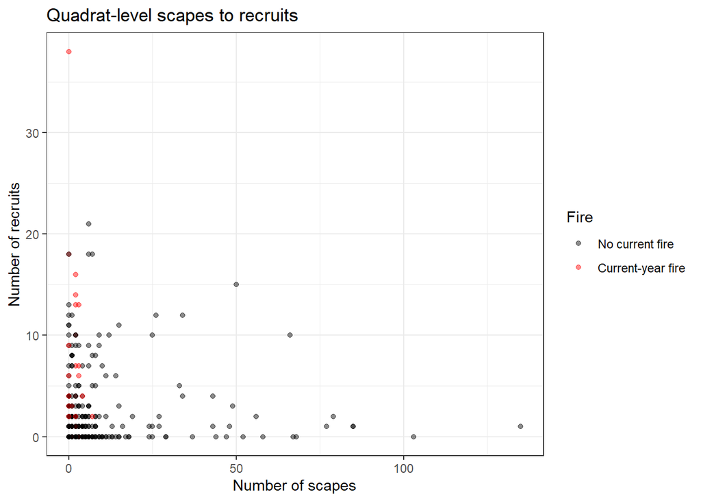

```r
fig_f2r_quad <- ggplot(
  df_f2r_quad %>%
    filter(
      !is.na(disturbance)),
  aes(
    x = scapes,
    y = recruits,
    color = factor(
      disturbance))) +
  geom_point(
    alpha = 0.45) +
  scale_color_manual(
    values = c(
      '0' = 'black',
      '1' = 'red'),
    labels = c(
      '0' = 'No current fire',
      '1' = 'Current-year fire'),
    name = 'Fire') +
  theme_bw() +
  labs(
    title = 'Quadrat-level scapes to recruits',
    x = 'Number of scapes',
    y = 'Number of recruits')

fig_f2r_quad
```

# Conversion back to individual fecundity

The recruitment model is fitted at site-population-year level. The IPM, however, requires expected recruitment from an individual plant.

The current implementation therefore predicts recruitment across the common observed distribution of site-population-year scape totals and divides the sum of predicted recruits by the total number of observed scapes. This produces one mean recruits-per-scape conversion for each current-fire state.

```r
get_recr_per_scape <- function(
    disturbance_i,
    year_i = NULL) {

  df_i <- df_sc2re_mod %>%
    mutate(
      disturbance =
        disturbance_i)

  if (is.null(year_i)) {
    re_form_i <- NA
  } else if (
      as.character(year_i) %in%
        levels(df_sc2re_mod$year)) {

    df_i <- df_i %>%
      mutate(
        year = factor(
          as.character(year_i),
          levels = levels(
            df_sc2re_mod$year)))

    re_form_i <- NULL
  } else {
    re_form_i <- NA
  }

  pred_i <- predict(
    mod_re_bestfit,
    newdata = df_i,
    type = 'response',
    re.form = re_form_i,
    allow.new.levels = TRUE)

  total_scapes_i <- sum(
    df_i$total_scapes,
    na.rm = TRUE)

  if (
      !is.finite(
        total_scapes_i) ||
      total_scapes_i <= 0) {
    return(0)
  }

  sum(
    pred_i,
    na.rm = TRUE) /
    total_scapes_i
}

recr_per_scape_0 <-
  get_recr_per_scape(0)

recr_per_scape_1 <-
  get_recr_per_scape(1)

tibble(
  disturbance = c(
    'No current fire',
    'Current-year fire'),
  recruits_per_scape = c(
    recr_per_scape_0,
    recr_per_scape_1)) %>%
  print(n = Inf)
```

```
## # A tibble: 2 × 2
##   disturbance       recruits_per_scape
##   <chr>                          <dbl>
## 1 No current fire                0.281
## 2 Current-year fire              1.19
```

For an individual of size $x$, this conversion is combined with flowering probability and expected scape number:

$$E(R \mid x) =
P(\mathrm{flower}\mid x)
\times
E(\mathrm{scapes}\mid \mathrm{flower},x)
\times
E(\mathrm{recruits\ per\ scape}).$$

Thus, the site-population-year recruitment model is brought back to the individual fecundity calculation through the recruits-per-scape term.

# Recruit size distribution

Recruit size is taken from individual records classified as seedlings.

```r
df_re_size <- df_ind %>%
  filter(
    recruit_type == 'seedling',
    size_t0 > 0,
    is.finite(logsize_t0))

recr_sz <- mean(
  df_re_size$logsize_t0,
  na.rm = TRUE)

recr_sd <- sd(
  df_re_size$logsize_t0,
  na.rm = TRUE)

recr_min <- min(
  df_re_size$logsize_t0,
  na.rm = TRUE)

recr_max <- max(
  df_re_size$logsize_t0,
  na.rm = TRUE)

normal_mass_observed_range <-
  pnorm(
    recr_max,
    mean = recr_sz,
    sd = recr_sd) -
  pnorm(
    recr_min,
    mean = recr_sz,
    sd = recr_sd)

tibble(
  n_seedlings = nrow(
    df_re_size),
  mean_logsize = recr_sz,
  sd_logsize = recr_sd,
  minimum_logsize = recr_min,
  maximum_logsize = recr_max,
  fitted_normal_mass_inside_observed_range =
    normal_mass_observed_range) %>%
  print(n = Inf)
```

```
## # A tibble: 1 × 6
##   n_seedlings mean_logsize sd_logsize minimum_logsize maximum_logsize
##         <int>        <dbl>      <dbl>           <dbl>           <dbl>
## 1         108        0.359      0.474           -1.20            1.79
## # ℹ 1 more variable: fitted_normal_mass_inside_observed_range <dbl>
```

## Observed recruit-size distribution

The histogram shows the observed seedling-size distribution. The line is the normal distribution defined by the observed mean and standard deviation, which is the distributional form used for recruits in the IPM.

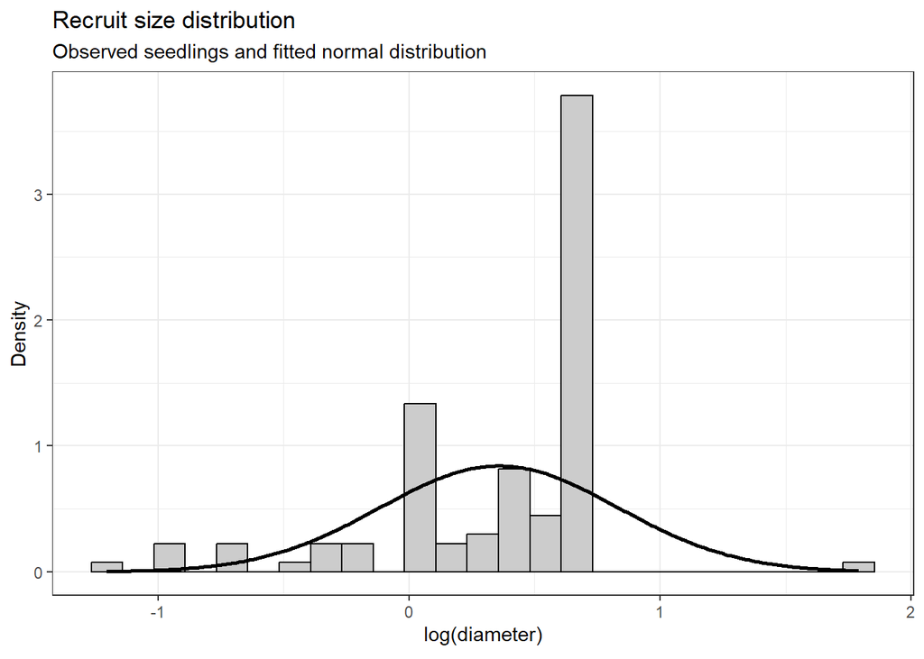

```r
df_re_size_density <- tibble(
  logsize_t0 = seq(
    recr_min,
    recr_max,
    length.out = 300)) %>%
  mutate(
    density = dnorm(
      logsize_t0,
      mean = recr_sz,
      sd = recr_sd))

fig_re_size <- ggplot(
  df_re_size,
  aes(
    logsize_t0)) +
  geom_histogram(
    aes(
      y = after_stat(
        density)),
    bins = 25,
    fill = 'grey80',
    color = 'black') +
  geom_line(
    data = df_re_size_density,
    aes(
      logsize_t0,
      density),
    linewidth = 1) +
  theme_bw() +
  labs(
    title = 'Recruit size distribution',
    subtitle = 'Observed seedlings and fitted normal distribution',
    x = expression(
      'log(diameter)'),
    y = 'Density')

fig_re_size
```

# Fecundity bookkeeping summary

The current fecundity process can therefore be summarized as follows.

```r
fecundity_bookkeeping <- tibble(
  component = c(
    'Flowering probability',
    'Scapes conditional on flowering',
    'Scapes to recruits',
    'Recruit size'),
  fitted_or_estimated_level = c(
    'Individual-year',
    'Individual-year',
    'Site-population-year',
    'Individual seedlings'),
  disturbance = c(
    'Previous-year fire',
    'Previous-year fire',
    'Current-year fire',
    'None'),
  IPM_quantity = c(
    'Probability of flowering',
    'Expected scapes conditional on flowering',
    'Recruits per scape',
    'Recruit size density'))

fecundity_bookkeeping %>%
  print(n = Inf)
```

```
## # A tibble: 4 × 4
##   component                      fitted_or_estimated_…¹ disturbance IPM_quantity
##   <chr>                          <chr>                  <chr>       <chr>
## 1 Flowering probability          Individual-year        Previous-y… Probability…
## 2 Scapes conditional on floweri… Individual-year        Previous-y… Expected sc…
## 3 Scapes to recruits             Site-population-year   Current-ye… Recruits pe…
## 4 Recruit size                   Individual seedlings   None        Recruit siz…
## # ℹ abbreviated name: ¹fitted_or_estimated_level
```

The fecundity contribution of an individual of size $x$ to recruits of size $y$ is represented by:

$$F(y,x) =
P(\mathrm{flower}\mid x)
\times
E(\mathrm{scapes}\mid \mathrm{flower},x)
\times
E(\mathrm{recruits\ per\ scape})
\times
f_{\mathrm{recruit\ size}}(y).$$

This section describes the current implementation only. The preceding tables and figures document the observational levels, disturbance coverage, fitted mean relationships, yearly relationships, recruitment aggregation, and recruit size distribution used in that implementation.